# ML для HR процессов

Проект по ML оптимизации процессов HR компании «Работа с заботой». Необходимо построить

- модель предсказания удовлетворенности сотрудников работой и
- модель предсказания увольнения сотрудников.

## Импорт библиотек

```python
import pandas as pd

import numpy as np

import matplotlib.pyplot as plt

import seaborn as sns

!pip3 install phik
import phik

!pip3 install shap
import shap

!pip3 install -U scikit-learn
from sklearn.model_selection import train_test_split, RandomizedSearchCV, GridSearchCV
from sklearn.pipeline import Pipeline
from sklearn.preprocessing import OneHotEncoder, OrdinalEncoder, StandardScaler, MinMaxScaler, RobustScaler
from sklearn.compose import ColumnTransformer
from sklearn.impute import SimpleImputer
from sklearn.metrics import roc_auc_score, make_scorer, mean_squared_error, RocCurveDisplay, roc_curve
from sklearn.linear_model import LogisticRegression, LinearRegression, Ridge
from sklearn.tree import DecisionTreeRegressor, plot_tree, DecisionTreeClassifier
from sklearn.neighbors import KNeighborsClassifier
from sklearn.svm import SVC
```

## Предсказание уровня удовлетворённости сотрудника

### Загрузка данных

```python
df_train = pd.read_csv('/datasets/train_job_satisfaction_rate.csv')

df_x_test = pd.read_csv('/datasets/test_features.csv')

df_y_test = pd.read_csv('/datasets/test_target_job_satisfaction_rate.csv')
```

```python
display(df_train.head())
```

|  | id | dept | level | workload | employment_years | last_year_promo | last_year_violations | supervisor_evaluation | salary | job_satisfaction_rate |
| --- | --- | --- | --- | --- | --- | --- | --- | --- | --- | --- |
| 0 | 155278 | sales | junior | medium | 2 | no | no | 1 | 24000 | 0.58 |
| 1 | 653870 | hr | junior | high | 2 | no | no | 5 | 38400 | 0.76 |
| 2 | 184592 | sales | junior | low | 1 | no | no | 2 | 12000 | 0.11 |
| 3 | 171431 | technology | junior | low | 4 | no | no | 2 | 18000 | 0.37 |
| 4 | 693419 | hr | junior | medium | 1 | no | no | 3 | 22800 | 0.20 |

```python
display(df_x_test.head())
```

|  | id | dept | level | workload | employment_years | last_year_promo | last_year_violations | supervisor_evaluation | salary |
| --- | --- | --- | --- | --- | --- | --- | --- | --- | --- |
| 0 | 485046 | marketing | junior | medium | 2 | no | no | 5 | 28800 |
| 1 | 686555 | hr | junior | medium | 1 | no | no | 4 | 30000 |
| 2 | 467458 | sales | middle | low | 5 | no | no | 4 | 19200 |
| 3 | 418655 | sales | middle | low | 6 | no | no | 4 | 19200 |
| 4 | 789145 | hr | middle | medium | 5 | no | no | 5 | 40800 |

```python
display(df_y_test.head())
```

|  | id | job_satisfaction_rate |
| --- | --- | --- |
| 0 | 130604 | 0.74 |
| 1 | 825977 | 0.75 |
| 2 | 418490 | 0.60 |
| 3 | 555320 | 0.72 |
| 4 | 826430 | 0.08 |

#### Вывод

Данные импортированы, датасеты не содержат странностей. Содержимое столбиков выглядит адекватно их названиям и заявленному содержимому.

### Предобработка данных

#### df_train

```python
df_train = df_train.set_index('id')
display(df_train.info())
print()
display(df_train.describe())

display(df_train.sample(5))
```

```
<class 'pandas.core.frame.DataFrame'>
Int64Index: 4000 entries, 155278 to 338347
Data columns (total 9 columns):
 #   Column                 Non-Null Count  Dtype
---  ------                 --------------  -----
 0   dept                   3994 non-null   object
 1   level                  3996 non-null   object
 2   workload               4000 non-null   object
 3   employment_years       4000 non-null   int64
 4   last_year_promo        4000 non-null   object
 5   last_year_violations   4000 non-null   object
 6   supervisor_evaluation  4000 non-null   int64
 7   salary                 4000 non-null   int64
 8   job_satisfaction_rate  4000 non-null   float64
dtypes: float64(1), int64(3), object(5)
memory usage: 312.5+ KB
```

```
None
```

|  | employment_years | supervisor_evaluation | salary | job_satisfaction_rate |
| --- | --- | --- | --- | --- |
| count | 4000.000000 | 4000.000000 | 4000.000000 | 4000.000000 |
| mean | 3.718500 | 3.476500 | 33926.700000 | 0.533995 |
| std | 2.542513 | 1.008812 | 14900.703838 | 0.225327 |
| min | 1.000000 | 1.000000 | 12000.000000 | 0.030000 |
| 25% | 2.000000 | 3.000000 | 22800.000000 | 0.360000 |
| 50% | 3.000000 | 4.000000 | 30000.000000 | 0.560000 |
| 75% | 6.000000 | 4.000000 | 43200.000000 | 0.710000 |
| max | 10.000000 | 5.000000 | 98400.000000 | 1.000000 |

| id | dept | level | workload | employment_years | last_year_promo | last_year_violations | supervisor_evaluation | salary | job_satisfaction_rate |
| --- | --- | --- | --- | --- | --- | --- | --- | --- | --- |
| 155278 | sales | junior | medium | 2 | no | no | 1 | 24000 | 0.58 |
| 653870 | hr | junior | high | 2 | no | no | 5 | 38400 | 0.76 |
| 184592 | sales | junior | low | 1 | no | no | 2 | 12000 | 0.11 |
| 171431 | technology | junior | low | 4 | no | no | 2 | 18000 | 0.37 |
| 693419 | hr | junior | medium | 1 | no | no | 3 | 22800 | 0.20 |
| ... | ... | ... | ... | ... | ... | ... | ... | ... | ... |
| 457950 | technology | junior | high | 2 | no | no | 3 | 46800 | 0.45 |
| 957499 | sales | junior | medium | 2 | no | no | 4 | 21600 | 0.68 |
| 533318 | sales | middle | low | 7 | no | no | 5 | 24000 | 0.76 |
| 706868 | sales | junior | medium | 2 | no | no | 3 | 24000 | 0.48 |
| 338347 | technology | middle | medium | 5 | no | yes | 1 | 44400 | 0.18 |

4000 rows × 9 columns

```python
print('Уникальные значения')
for column in df_train.select_dtypes(include=[object]).columns:
    print(df_train[column].unique())

df_train = df_train.replace('sinior', 'senior')
print()

print('Пропусков найдено:', df_train.isna().sum())
df_train[df_train.isna().any(axis=1)]

print()

print('Полные дубликаты', df_train.duplicated().sum())

df_train = df_train.drop_duplicates()

print('Полные дубликаты после удаления', df_train.duplicated().sum())
```

```
Уникальные значения
['sales' 'hr' 'technology' 'purchasing' 'marketing' nan]
['junior' 'middle' 'sinior' nan]
['medium' 'high' 'low']
['no' 'yes']
['no' 'yes']

Пропусков найдено: dept                     6
level                    4
workload                 0
employment_years         0
last_year_promo          0
last_year_violations     0
supervisor_evaluation    0
salary                   0
job_satisfaction_rate    0
dtype: int64

Полные дубликаты 245
Полные дубликаты после удаления 0
```

#### Вывод по df_train

Устранена одна опечатка, полные дубликаты (без учета id) удалены, пропуски будут удалены далее в пайплайне обработки данных.

#### df_x_test

```python
df_x_test = df_x_test.set_index('id')
display(df_x_test.info())
print()
display(df_x_test.describe())
display(df_x_test.sample(5))
```

```
<class 'pandas.core.frame.DataFrame'>
Int64Index: 2000 entries, 485046 to 771859
Data columns (total 8 columns):
 #   Column                 Non-Null Count  Dtype
---  ------                 --------------  -----
 0   dept                   1998 non-null   object
 1   level                  1999 non-null   object
 2   workload               2000 non-null   object
 3   employment_years       2000 non-null   int64
 4   last_year_promo        2000 non-null   object
 5   last_year_violations   2000 non-null   object
 6   supervisor_evaluation  2000 non-null   int64
 7   salary                 2000 non-null   int64
dtypes: int64(3), object(5)
memory usage: 140.6+ KB
```

```
None
```

|  | employment_years | supervisor_evaluation | salary |
| --- | --- | --- | --- |
| count | 2000.000000 | 2000.000000 | 2000.000000 |
| mean | 3.666500 | 3.526500 | 34066.800000 |
| std | 2.537222 | 0.996892 | 15398.436729 |
| min | 1.000000 | 1.000000 | 12000.000000 |
| 25% | 1.000000 | 3.000000 | 22800.000000 |
| 50% | 3.000000 | 4.000000 | 30000.000000 |
| 75% | 6.000000 | 4.000000 | 43200.000000 |
| max | 10.000000 | 5.000000 | 96000.000000 |

| id | dept | level | workload | employment_years | last_year_promo | last_year_violations | supervisor_evaluation | salary |
| --- | --- | --- | --- | --- | --- | --- | --- | --- |
| 485046 | marketing | junior | medium | 2 | no | no | 5 | 28800 |
| 686555 | hr | junior | medium | 1 | no | no | 4 | 30000 |
| 467458 | sales | middle | low | 5 | no | no | 4 | 19200 |
| 418655 | sales | middle | low | 6 | no | no | 4 | 19200 |
| 789145 | hr | middle | medium | 5 | no | no | 5 | 40800 |
| ... | ... | ... | ... | ... | ... | ... | ... | ... |
| 393147 | marketing | junior | low | 3 | no | no | 3 | 20400 |
| 109582 | technology | middle | low | 3 | no | no | 2 | 21600 |
| 305653 | technology | junior | low | 1 | no | no | 3 | 14400 |
| 160233 | technology | middle | low | 8 | no | no | 1 | 32400 |
| 771859 | purchasing | middle | medium | 1 | no | no | 4 | 38400 |

2000 rows × 8 columns

```python
print('Уникальные значения')
for column in df_x_test.select_dtypes(include=[object]).columns:
    print(df_x_test[column].unique())

df_x_test = df_x_test.replace('sinior', 'senior')
print()

print('Пропусков найдено:', df_x_test.isna().sum() )
df_x_test[df_x_test.isna().any(axis=1)]

print()

print('Полные дубликаты', df_x_test.duplicated().sum())

df_x_test = df_x_test.drop_duplicates()

print('Полные дубликаты после удаления', df_x_test.duplicated().sum())
```

```
Уникальные значения
['marketing' 'hr' 'sales' 'purchasing' 'technology' nan ' ']
['junior' 'middle' 'sinior' nan]
['medium' 'low' 'high' ' ']
['no' 'yes']
['no' 'yes']

Пропусков найдено: dept                     2
level                    1
workload                 0
employment_years         0
last_year_promo          0
last_year_violations     0
supervisor_evaluation    0
salary                   0
dtype: int64

Полные дубликаты 557
Полные дубликаты после удаления 0
```

#### Вывод по df_x_test

Устранена одна опечатка, полные дубликаты (без учета id) удалены, пропуски будут удалены далее.

#### df_y_test

```python
df_y_test = df_y_test.set_index('id')
display(df_y_test.info())
print()
display(df_y_test.describe())
display(df_y_test.sample(5))
```

```
<class 'pandas.core.frame.DataFrame'>
Int64Index: 2000 entries, 130604 to 648995
Data columns (total 1 columns):
 #   Column                 Non-Null Count  Dtype
---  ------                 --------------  -----
 0   job_satisfaction_rate  2000 non-null   float64
dtypes: float64(1)
memory usage: 31.2 KB
```

```
None
```

|  | job_satisfaction_rate |
| --- | --- |
| count | 2000.00000 |
| mean | 0.54878 |
| std | 0.22011 |
| min | 0.03000 |
| 25% | 0.38000 |
| 50% | 0.58000 |
| 75% | 0.72000 |
| max | 1.00000 |

| id | job_satisfaction_rate |
| --- | --- |
| 130604 | 0.74 |
| 825977 | 0.75 |
| 418490 | 0.60 |
| 555320 | 0.72 |
| 826430 | 0.08 |
| ... | ... |
| 405257 | 0.28 |
| 370925 | 0.21 |
| 857722 | 0.39 |
| 303402 | 0.26 |
| 648995 | 0.62 |

2000 rows × 1 columns

```python
for column in df_y_test.select_dtypes(include=[object]).columns:
    print(df_y_test[column].unique())

df_y_test = df_y_test.replace('sinior', 'senior')
print()

print('Пропусков найдено:', df_y_test.isna().sum() )
df_y_test[df_y_test.isna().any(axis=1)]
```

```
Пропусков найдено: job_satisfaction_rate    0
dtype: int64
```

#### Вывод по df_y_test

Проблем с данными не обнаружено.

### Исследовательский анализ данных

```python
# Функция построения корреляционной матрицы данных
def corr_max(df):
    plt.figure(figsize = (16,6))
    corr = df.phik_matrix()
    sns.heatmap(corr, cmap="Blues", annot=True)
    return

# Функция построения Pie диграмм данных типа object
def barplotter(df):
    for column in df.select_dtypes(include=[object]).columns:
        print(column, 'анализ')
        display(df[column].describe())
        print()
        plt.figure(figsize=(16, 4))
        df[column].value_counts(dropna=False).plot(kind="pie", autopct='%1.0f%%', figsize=(11, 6))
        plt.title(column)
        plt.show()
    return

# Функция построения гистограмм численных данных
def histplotter(df):
    for column in df.select_dtypes(exclude=[object]).columns:
        print(column, 'анализ')
        display(df[column].describe())
        plt.figure(figsize=(16, 5))
        plt.hist(df[column], align='mid', bins = np.min([len(df[column].unique()), 20]))
        plt.xlabel(column)
        plt.ylabel('Frequency')
        plt.show()
        print()
        plt.figure(figsize=(16, 5))
        plt.boxplot(df[column])
        plt.xlabel(column)
        plt.show()
    return
```

#### Анализ df_train

```
Анализ df_train
interval columns not set, guessing: ['employment_years', 'supervisor_evaluation', 'salary', 'job_satisfaction_rate']
```

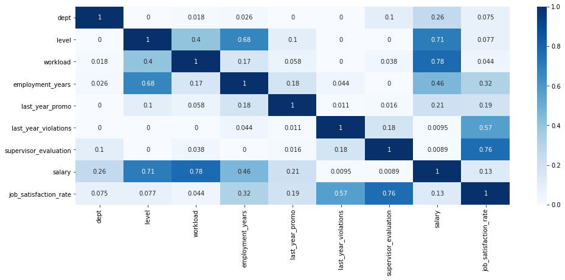

```python
print('Анализ df_train')
corr_max(df_train)
```

```
Pie диаграммы тренировочной выборки

dept анализ
```

```
count      3749
unique        5
top       sales
freq       1374
Name: dept, dtype: object
```

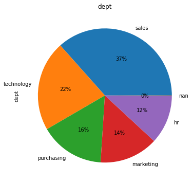

```
level анализ
```

```
count       3751
unique         3
top       junior
freq        1699
Name: level, dtype: object
```

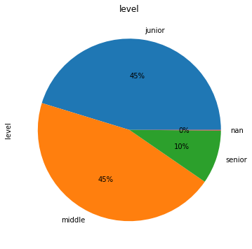

```
workload анализ
```

```
count       3755
unique         3
top       medium
freq        1908
Name: workload, dtype: object
```

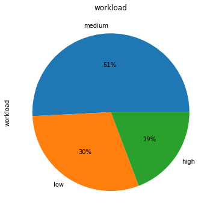

```
last_year_promo анализ
```

```
count     3755
unique       2
top         no
freq      3635
Name: last_year_promo, dtype: object
```

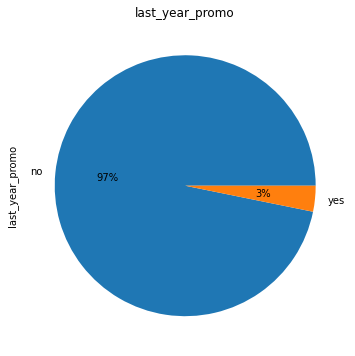

```
last_year_violations анализ
```

```
count     3755
unique       2
top         no
freq      3202
Name: last_year_violations, dtype: object
```

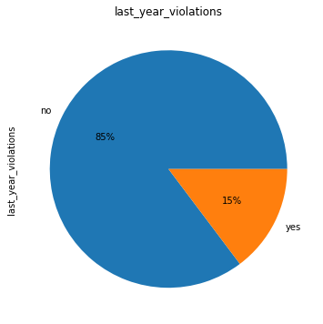

```python
print('Pie диаграммы тренировочной выборки')
print()
barplotter(df_train)
```

```
Гистограммы и Box диаграммы тренировочной выборки

employment_years анализ
```

```
count    3755.000000
mean        3.817044
std         2.557142
min         1.000000
25%         2.000000
50%         3.000000
75%         6.000000
max        10.000000
Name: employment_years, dtype: float64
```

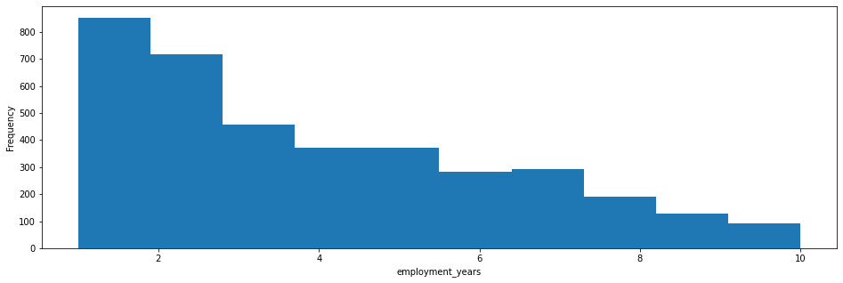

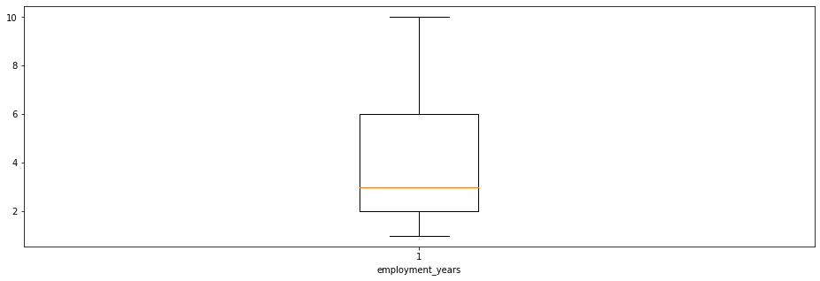

```
supervisor_evaluation анализ
```

```
count    3755.000000
mean        3.463648
std         1.026265
min         1.000000
25%         3.000000
50%         4.000000
75%         4.000000
max         5.000000
Name: supervisor_evaluation, dtype: float64
```

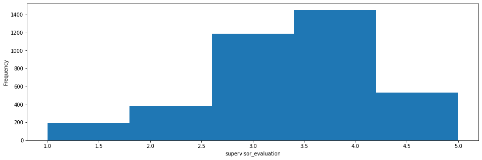

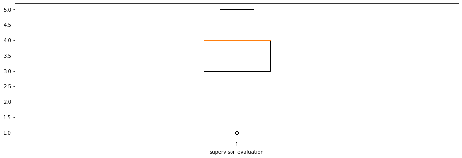

```
salary анализ
```

```
count     3755.000000
mean     34457.416778
std      15050.643870
min      12000.000000
25%      22800.000000
50%      31200.000000
75%      44400.000000
max      98400.000000
Name: salary, dtype: float64
```

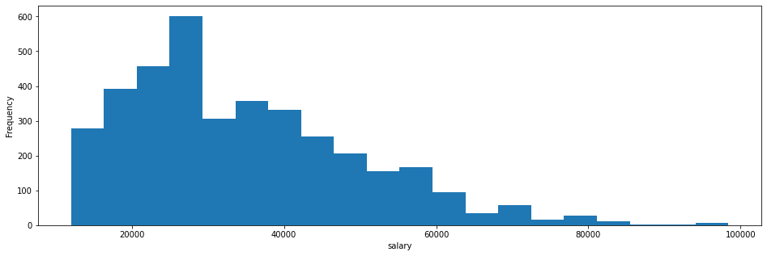

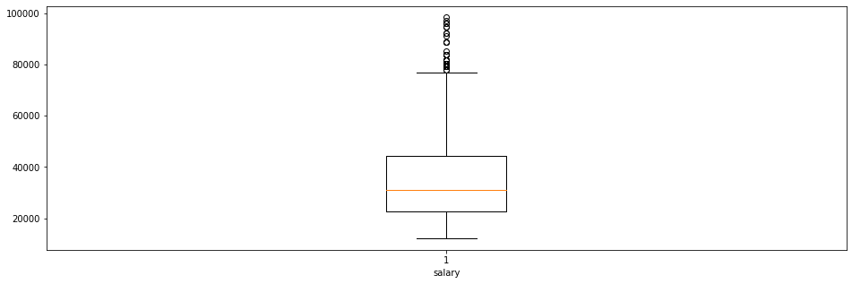

```
job_satisfaction_rate анализ
```

```
count    3755.000000
mean        0.532554
std         0.226393
min         0.030000
25%         0.350000
50%         0.550000
75%         0.710000
max         1.000000
Name: job_satisfaction_rate, dtype: float64
```

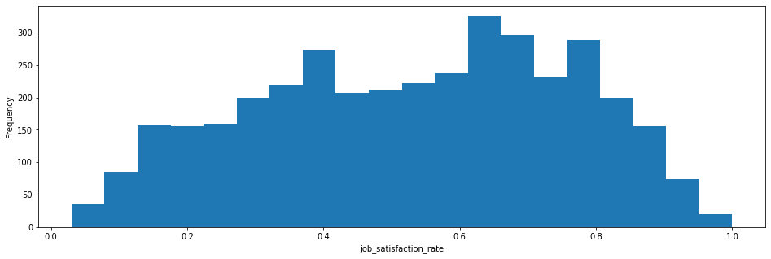

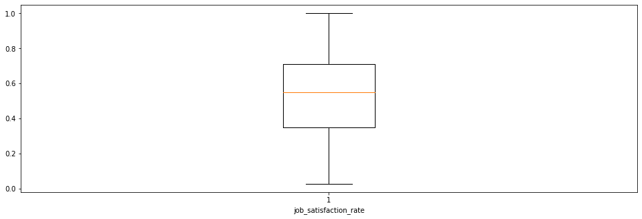

```python
print('Гистограммы и Box диаграммы тренировочной выборки')
print()
histplotter(df_train)
print()
```

#### Выводы по df_train

Аномалий в данных не обнаружено. Каждый из параметров имеет разный характер распределения. Корреляционный анализ показал ожидаемую сильную взаимосвязь некоторых параметров:

- рабочая нагрузка и уровень vs зарплата,
- удовлетворенность работой и оценка руководителя,
- стаж работы и уровень.

#### Анализ df_x_test

```
Анализ df_x_test - входные параметры тестовой выборки
interval columns not set, guessing: ['employment_years', 'supervisor_evaluation', 'salary']
```

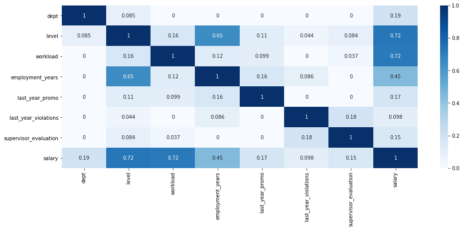

```python
print('Анализ df_x_test - входные параметры тестовой выборки')
corr_max(df_x_test)
```

```
Pie диаграммы входных параметров тестовой выборки

dept анализ
```

```
count      1441
unique        6
top       sales
freq        464
Name: dept, dtype: object
```

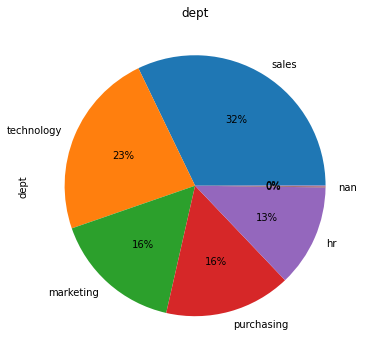

```
level анализ
```

```
count       1442
unique         3
top       middle
freq         723
Name: level, dtype: object
```

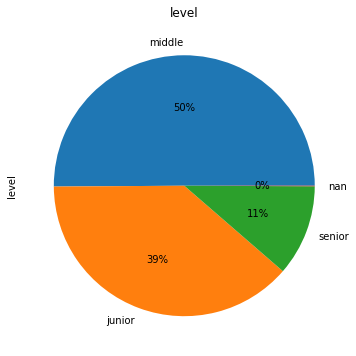

```
workload анализ
```

```
count       1443
unique         4
top       medium
freq         700
Name: workload, dtype: object
```

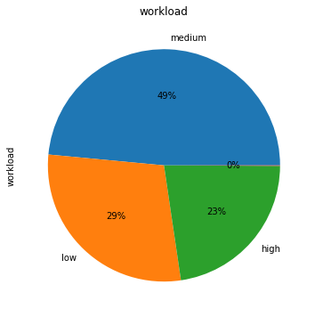

```
last_year_promo анализ
```

```
count     1443
unique       2
top         no
freq      1381
Name: last_year_promo, dtype: object
```

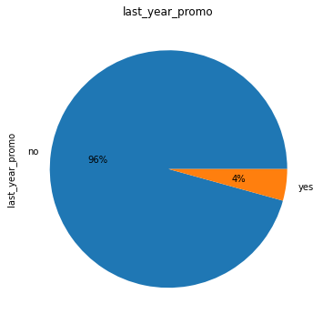

```
last_year_violations анализ
```

```
count     1443
unique       2
top         no
freq      1202
Name: last_year_violations, dtype: object
```

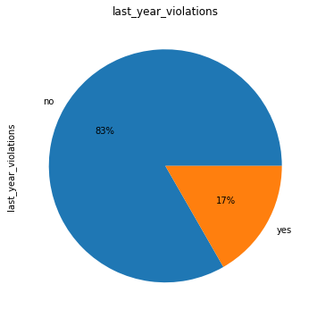

```python
print('Pie диаграммы входных параметров тестовой выборки')
print()
barplotter(df_x_test)
```

```
Гистограммы и Box диаграммы входных параметров тестовой выборки

employment_years анализ
```

```
count    1443.000000
mean        4.115038
std         2.578168
min         1.000000
25%         2.000000
50%         4.000000
75%         6.000000
max        10.000000
Name: employment_years, dtype: float64
```

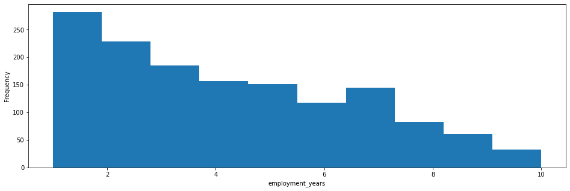

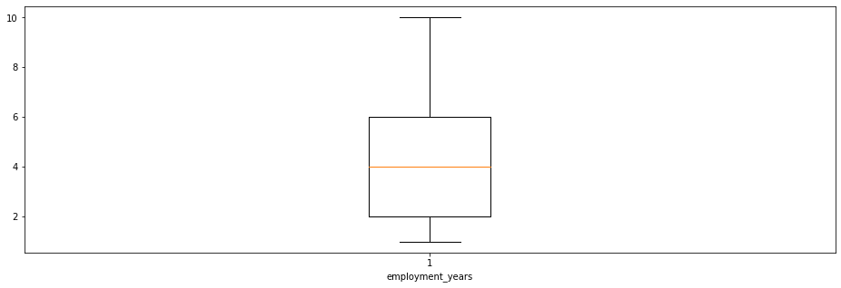

```
supervisor_evaluation анализ
```

```
count    1443.000000
mean        3.444906
std         1.069813
min         1.000000
25%         3.000000
50%         4.000000
75%         4.000000
max         5.000000
Name: supervisor_evaluation, dtype: float64
```

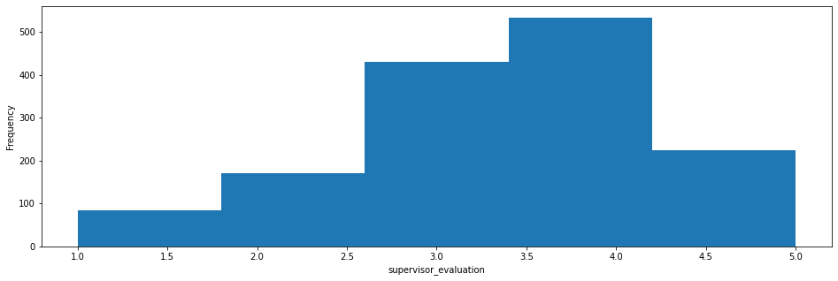

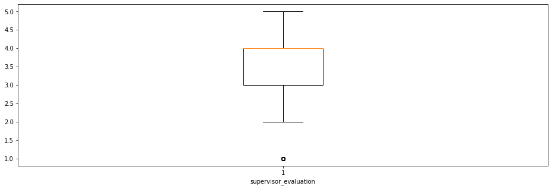

```
salary анализ
```

```
count     1443.000000
mean     36653.638254
std      16175.366290
min      12000.000000
25%      24000.000000
50%      33600.000000
75%      46800.000000
max      96000.000000
Name: salary, dtype: float64
```

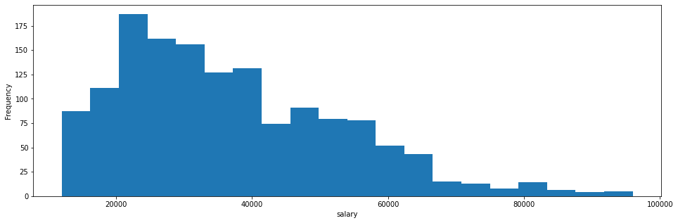

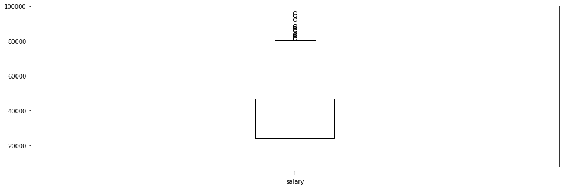

```python
print('Гистограммы и Box диаграммы входных параметров тестовой выборки')
print()
histplotter(df_x_test)
print()
```

#### Выводы по df_x_test

При этом мультиколлинеарности не зарегистрировано.

#### Анализ df_y_test

```
Гистограмма и Box диаграмма целевого параметра тестовой выборки

job_satisfaction_rate анализ
```

```
count    2000.00000
mean        0.54878
std         0.22011
min         0.03000
25%         0.38000
50%         0.58000
75%         0.72000
max         1.00000
Name: job_satisfaction_rate, dtype: float64
```

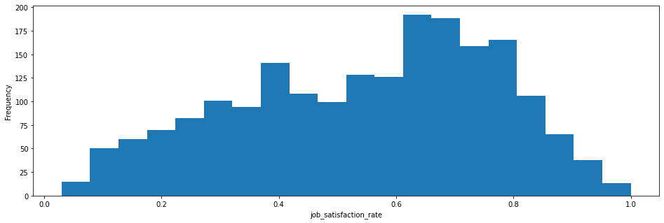

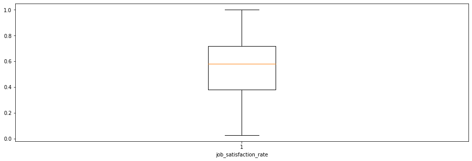

```python
print('Гистограмма и Box диаграмма целевого параметра тестовой выборки')
print()
histplotter(df_y_test)
print()
```

#### Выводы по df_y_test

Аномалий в данных не обнаружено. Целевой признак в тестовой выборке имеет ненормальное распределение.

### Подготовка данных

```python
RANDOM_STATE = 42

X_train = df_train.drop(['job_satisfaction_rate'], axis = 1)
y_train = df_train['job_satisfaction_rate']

y_test = df_x_test.join(df_y_test, how = 'left')['job_satisfaction_rate']
X_test = df_x_test.join(df_y_test, how = 'left').drop(['job_satisfaction_rate'], axis = 1)

# Создаём списки с названиями признаков
num_columns = ['employment_years', 'supervisor_evaluation', 'salary']
ohe_columns = ['dept', 'last_year_promo', 'last_year_violations']
ord_columns = ['level', 'workload']

# Создаём пайплайн для подготовки признаков из списка ohe_columns: заполнение пропусков и OHE-кодирование
# SimpleImputer + OHE
ohe_pipe = Pipeline(
    [('simpleImputer_ohe', SimpleImputer(missing_values=np.nan, strategy='most_frequent')),
     ('ohe', OneHotEncoder(drop='first', handle_unknown='ignore', sparse_output=False))
    ]
    )

# Создаём пайплайн для подготовки признаков из списка ord_columns: заполнение пропусков и Ordinal-кодирование
# SimpleImputer + OE
ord_pipe = Pipeline(
    [('simpleImputer_before_ord', SimpleImputer(missing_values=np.nan, strategy='most_frequent')),
     ('ord',  OrdinalEncoder(
                categories=[
                    ['junior', 'middle', 'senior'],
                    ['low', 'medium', 'high']
                ],
                handle_unknown='use_encoded_value', unknown_value=-1 #unknown_value=np.nan
            )
        ),
     ('simpleImputer_after_ord', SimpleImputer(missing_values=np.nan, strategy='most_frequent'))
    ]
)

# Создаём общий пайплайн для подготовки данных
data_preprocessor = ColumnTransformer(
    [('ohe', ohe_pipe, ohe_columns),
     ('ord', ord_pipe, ord_columns),
     ('num', MinMaxScaler(), num_columns)
    ],
    remainder='passthrough'
)
```

#### Выводы по подготовке данных

Создан пайплайн подготовки данных, при создании учтено содержимое входных данных: численное, категориальные и категориальный ранговые, использованы OneHotEncoder и OrdinalEncoder соответственно.

### Обучение моделей

```python
# Создаём итоговый пайплайн: подготовка данных и модель
pipe_final = Pipeline([
    ('preprocessor', data_preprocessor),
    ('models', DecisionTreeRegressor(random_state=RANDOM_STATE))
])

# Сетка параметров для перебора
param_grid = [
    # Словарь для модели DecisionTreeRegressor()
    {
        'models': [DecisionTreeRegressor(random_state=RANDOM_STATE)],
        'models__max_depth': range(5,30),
        #'models__max_depth': None,
        #'models__max_features': range(2,30),
        'models__max_features': range(5,15),
        'preprocessor__num': [StandardScaler(), MinMaxScaler(), 'passthrough']
    },

    # Словарь для модели LinearRegression()
    {
        'models': [LinearRegression(
        )],
        'preprocessor__num': [StandardScaler(), MinMaxScaler(), 'passthrough']
    },

    # Словарь для модели Ridge()
    {
        'models': [Ridge(random_state=RANDOM_STATE
        )],
        'models__alpha': range(1,5),
        'preprocessor__num': [StandardScaler(), MinMaxScaler(), 'passthrough']
    }
]

# Создаем метрику SMAPE
def SMAPE(y_pred, y_true):
    test = y_true
    pred = y_pred
    return 100/len(test) * np.sum(np.abs(pred - test) / ((np.abs(test) + np.abs(pred))*0.5))

SMAPE_score = make_scorer(SMAPE,greater_is_better=False)


randomized_search = RandomizedSearchCV(
    pipe_final,
    param_grid,
    cv=5,
    n_iter = 50,
    scoring=SMAPE_score,
    random_state=RANDOM_STATE,
    n_jobs=-1
)

randomized_search.fit(X_train, y_train)

print('Лучшая модель и её параметры:\n\n', randomized_search.best_estimator_)
print()
print ('Метрика SMAPE лучшей модели на тренировочной выборке:', np.abs(randomized_search.best_score_))

# Лучшая модель
best_model = randomized_search.best_estimator_.named_steps['models']

# Подготовка данных
x_Train = randomized_search.best_estimator_.named_steps['preprocessor'].fit_transform(X_train)
x_Test = randomized_search.best_estimator_.named_steps['preprocessor'].transform(X_test)

print ('Метрика SMAPE лучшей модели на тестовой выборке:', SMAPE(best_model.predict(x_Test), y_test))
```

```
Лучшая модель и её параметры:

 Pipeline(steps=[('preprocessor',
                 ColumnTransformer(remainder='passthrough',
                                   transformers=[('ohe',
                                                  Pipeline(steps=[('simpleImputer_ohe',
                                                                   SimpleImputer(strategy='most_frequent')),
                                                                  ('ohe',
                                                                   OneHotEncoder(drop='first',
                                                                                 handle_unknown='ignore',
                                                                                 sparse_output=False))]),
                                                  ['dept', 'last_year_promo',
                                                   'last_year_violations']),
                                                 ('ord',
                                                  Pipeline(steps=[('simpleImputer_befor...
                                                                   OrdinalEncoder(categories=[['junior',
                                                                                               'middle',
                                                                                               'senior'],
                                                                                              ['low',
                                                                                               'medium',
                                                                                               'high']],
                                                                                  handle_unknown='use_encoded_value',
                                                                                  unknown_value=-1)),
                                                                  ('simpleImputer_after_ord',
                                                                   SimpleImputer(strategy='most_frequent'))]),
                                                  ['level', 'workload']),
                                                 ('num', MinMaxScaler(),
                                                  ['employment_years',
                                                   'supervisor_evaluation',
                                                   'salary'])])),
                ('models',
                 DecisionTreeRegressor(max_depth=12, max_features=8,
                                       random_state=42))])

Метрика SMAPE лучшей модели на тренировочной выборке: 15.596802397483746
Метрика SMAPE лучшей модели на тестовой выборке: 16.349547303863027
```

```
Found unknown categories in columns [0] during transform. These unknown categories will be encoded as all zeros
```

```python
# Результаты оптимизации модели 1
cv_results = pd.DataFrame(randomized_search.cv_results_)
cv_results.sample(5)
```

|  | mean_fit_time | std_fit_time | mean_score_time | std_score_time | param_preprocessor__num | param_models__max_features | param_models__max_depth | param_models | param_models__alpha | params | split0_test_score | split1_test_score | split2_test_score | split3_test_score | split4_test_score | mean_test_score | std_test_score | rank_test_score |
| --- | --- | --- | --- | --- | --- | --- | --- | --- | --- | --- | --- | --- | --- | --- | --- | --- | --- | --- |
| 24 | 0.033379 | 0.001596 | 0.012169 | 0.001462 | StandardScaler() | 11 | 20 | DecisionTreeRegressor(random_state=42) | NaN | {'preprocessor__num': StandardScaler(), 'model... | -15.852790 | -14.960777 | -16.863558 | -16.256557 | -15.940575 | -15.974851 | 0.618640 | 11 |
| 47 | 0.023792 | 0.001226 | 0.008675 | 0.000539 | passthrough | 6 | 10 | DecisionTreeRegressor(random_state=42) | NaN | {'preprocessor__num': 'passthrough', 'models__... | -17.455694 | -16.097951 | -16.771426 | -17.179069 | -17.031945 | -16.907217 | 0.461224 | 39 |
| 46 | 0.033947 | 0.004333 | 0.011715 | 0.002761 | MinMaxScaler() | 6 | 23 | DecisionTreeRegressor(random_state=42) | NaN | {'preprocessor__num': MinMaxScaler(), 'models_... | -15.560294 | -15.827272 | -16.665875 | -16.584309 | -15.669096 | -16.061369 | 0.468754 | 15 |
| 26 | 0.032131 | 0.005411 | 0.011740 | 0.001748 | StandardScaler() | 11 | 7 | DecisionTreeRegressor(random_state=42) | NaN | {'preprocessor__num': StandardScaler(), 'model... | -18.288829 | -16.870524 | -19.076342 | -18.826786 | -18.662191 | -18.344934 | 0.780362 | 42 |
| 27 | 0.033676 | 0.002987 | 0.010876 | 0.001370 | StandardScaler() | 10 | 21 | DecisionTreeRegressor(random_state=42) | NaN | {'preprocessor__num': StandardScaler(), 'model... | -16.049578 | -15.190781 | -16.538336 | -16.559016 | -16.355663 | -16.138675 | 0.507925 | 21 |

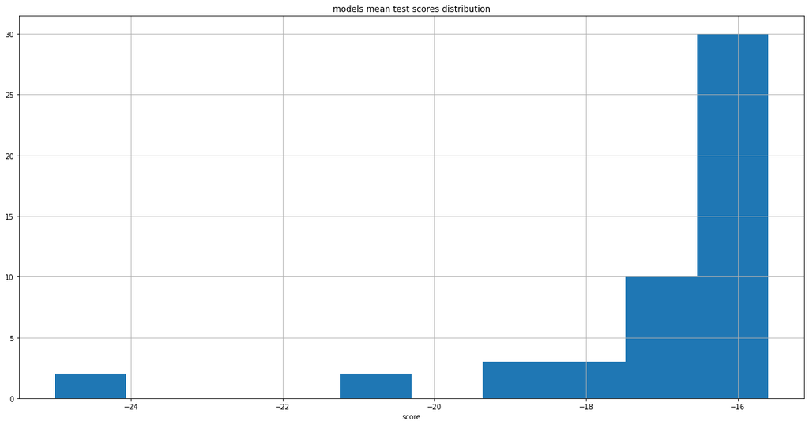

```python
# Выводим mean_test_score
plt.figure(figsize = (20,10))

model_list = list(cv_results['params'])
'''
(pd.Series(cv_results['mean_test_score'])
  .nlargest(10)
   .plot(kind='barh'))
'''

(cv_results['mean_test_score']).hist()
plt.xlabel('score')
plt.title('models mean test scores distribution')
```

#### Интерпретация модели 1

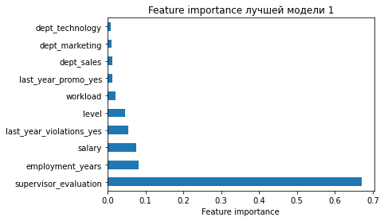

```python
# Анализируем feature_importance лучшей модели
feature_name_list = randomized_search.best_estimator_.named_steps['preprocessor'].transformers_[0][1]['ohe'].get_feature_names_out(ohe_columns).tolist() + ord_columns + num_columns

(pd.Series(best_model.feature_importances_, index=feature_name_list)
  .nlargest(10)
   .plot(kind='barh'))

plt.title('Feature importance лучшей модели 1');
plt.xlabel('Feature importance')
```

#### Выводы по обучению моделей

Был построен пайплайн для подготовки данных и подбора оптимальной модели предсказания уровня удовлетворенности - выбор производился между LinearRegression, Ridge и DecisionTreeRegressor у каждой модели был задан диапазон изменения гиперпараметров для оптимизации.

Метрика SMAPE лучшей модели на тренировочной выборке: 15.6 Метрика SMAPE лучшей модели на тестовой выборке: 16.35

Модель DecisionTreeRegressor с параметрами max_depth=12, max_features=8 и функцией масштабирования MinMaxScaler продемонстрировала лучшую метрику в ходе оптимизации (SMAPE = 15.6 на тренировочной выборке) и на тестовой выборке выдала значение SMAPE = 16.35, что хуже критерия успеха (SMAPE <= 15), тем не менее после удаления дубликатов данных из всех выборок не удалось добиться лучшего результата (в том числе исключением параметров dept и workload из входящих данных при обучении и предсказании).

## Предсказание увольнения сотрудника из компании

```python
df_train_2 = pd.read_csv('/datasets/train_quit.csv')

df_x_test_2 = pd.read_csv('/datasets/test_features.csv')

df_y_test_2 = pd.read_csv('/datasets/test_target_quit.csv')
```

```python
display(df_train_2.head())
```

|  | id | dept | level | workload | employment_years | last_year_promo | last_year_violations | supervisor_evaluation | salary | quit |
| --- | --- | --- | --- | --- | --- | --- | --- | --- | --- | --- |
| 0 | 723290 | sales | middle | high | 2 | no | no | 4 | 54000 | no |
| 1 | 814010 | sales | junior | medium | 2 | no | no | 4 | 27600 | no |
| 2 | 155091 | purchasing | middle | medium | 5 | no | no | 1 | 37200 | no |
| 3 | 257132 | sales | junior | medium | 2 | no | yes | 3 | 24000 | yes |
| 4 | 910140 | marketing | junior | medium | 2 | no | no | 5 | 25200 | no |

```python
display(df_x_test_2.head())
```

|  | id | dept | level | workload | employment_years | last_year_promo | last_year_violations | supervisor_evaluation | salary |
| --- | --- | --- | --- | --- | --- | --- | --- | --- | --- |
| 0 | 485046 | marketing | junior | medium | 2 | no | no | 5 | 28800 |
| 1 | 686555 | hr | junior | medium | 1 | no | no | 4 | 30000 |
| 2 | 467458 | sales | middle | low | 5 | no | no | 4 | 19200 |
| 3 | 418655 | sales | middle | low | 6 | no | no | 4 | 19200 |
| 4 | 789145 | hr | middle | medium | 5 | no | no | 5 | 40800 |

```python
display(df_y_test_2.head())
```

|  | id | quit |
| --- | --- | --- |
| 0 | 999029 | yes |
| 1 | 372846 | no |
| 2 | 726767 | no |
| 3 | 490105 | no |
| 4 | 416898 | yes |

#### Вывод

Данные импортированы, датасеты не содержат странностей. Содержимое столбиков выглядит адекватно их названиям и заявленному содержимому.

### Предобработка данных

#### df_train_2

```python
df_train_2 = df_train_2.set_index('id')
display(df_train_2.info())
print()
display(df_train_2.describe())
display(df_train_2.sample(5))
```

```
<class 'pandas.core.frame.DataFrame'>
Int64Index: 4000 entries, 723290 to 853842
Data columns (total 9 columns):
 #   Column                 Non-Null Count  Dtype
---  ------                 --------------  -----
 0   dept                   4000 non-null   object
 1   level                  4000 non-null   object
 2   workload               4000 non-null   object
 3   employment_years       4000 non-null   int64
 4   last_year_promo        4000 non-null   object
 5   last_year_violations   4000 non-null   object
 6   supervisor_evaluation  4000 non-null   int64
 7   salary                 4000 non-null   int64
 8   quit                   4000 non-null   object
dtypes: int64(3), object(6)
memory usage: 312.5+ KB
```

```
None
```

|  | employment_years | supervisor_evaluation | salary |
| --- | --- | --- | --- |
| count | 4000.000000 | 4000.000000 | 4000.000000 |
| mean | 3.701500 | 3.474750 | 33805.800000 |
| std | 2.541852 | 1.004049 | 15152.415163 |
| min | 1.000000 | 1.000000 | 12000.000000 |
| 25% | 2.000000 | 3.000000 | 22800.000000 |
| 50% | 3.000000 | 4.000000 | 30000.000000 |
| 75% | 6.000000 | 4.000000 | 43200.000000 |
| max | 10.000000 | 5.000000 | 96000.000000 |

| id | dept | level | workload | employment_years | last_year_promo | last_year_violations | supervisor_evaluation | salary | quit |
| --- | --- | --- | --- | --- | --- | --- | --- | --- | --- |
| 723290 | sales | middle | high | 2 | no | no | 4 | 54000 | no |
| 814010 | sales | junior | medium | 2 | no | no | 4 | 27600 | no |
| 155091 | purchasing | middle | medium | 5 | no | no | 1 | 37200 | no |
| 257132 | sales | junior | medium | 2 | no | yes | 3 | 24000 | yes |
| 910140 | marketing | junior | medium | 2 | no | no | 5 | 25200 | no |
| ... | ... | ... | ... | ... | ... | ... | ... | ... | ... |
| 588809 | sales | junior | medium | 4 | no | no | 3 | 26400 | no |
| 672059 | sales | middle | high | 9 | no | no | 4 | 52800 | no |
| 536432 | purchasing | junior | low | 2 | no | yes | 4 | 12000 | yes |
| 692133 | purchasing | middle | medium | 2 | no | no | 4 | 33600 | no |
| 853842 | sales | junior | medium | 2 | no | no | 3 | 27600 | yes |

4000 rows × 9 columns

```python
print('Уникальные значения')
for column in df_train_2.select_dtypes(include=[object]).columns:
    print(df_train_2[column].unique())

df_train_2 = df_train_2.replace('sinior', 'senior')
print()

print('Пропусков найдено:', df_train.isna().sum() )
df_train_2[df_train_2.isna().any(axis=1)]

print()

print('Полные дубликаты', df_train_2.duplicated().sum())

df_train_2 = df_train_2.drop_duplicates()

print('Полные дубликаты после удаления', df_train_2.duplicated().sum())
```

```
Уникальные значения
['sales' 'purchasing' 'marketing' 'technology' 'hr']
['middle' 'junior' 'sinior']
['high' 'medium' 'low']
['no' 'yes']
['no' 'yes']
['no' 'yes']

Пропусков найдено: dept                     6
level                    4
workload                 0
employment_years         0
last_year_promo          0
last_year_violations     0
supervisor_evaluation    0
salary                   0
job_satisfaction_rate    0
dtype: int64

Полные дубликаты 1413
Полные дубликаты после удаления 0
```

#### df_x_test_2

```python
df_x_test_2 = df_x_test_2.set_index('id')
display(df_x_test_2.info())
print()
display(df_x_test_2.describe())
display(df_x_test_2.sample(5))
```

```
<class 'pandas.core.frame.DataFrame'>
Int64Index: 2000 entries, 485046 to 771859
Data columns (total 8 columns):
 #   Column                 Non-Null Count  Dtype
---  ------                 --------------  -----
 0   dept                   1998 non-null   object
 1   level                  1999 non-null   object
 2   workload               2000 non-null   object
 3   employment_years       2000 non-null   int64
 4   last_year_promo        2000 non-null   object
 5   last_year_violations   2000 non-null   object
 6   supervisor_evaluation  2000 non-null   int64
 7   salary                 2000 non-null   int64
dtypes: int64(3), object(5)
memory usage: 140.6+ KB
```

```
None
```

|  | employment_years | supervisor_evaluation | salary |
| --- | --- | --- | --- |
| count | 2000.000000 | 2000.000000 | 2000.000000 |
| mean | 3.666500 | 3.526500 | 34066.800000 |
| std | 2.537222 | 0.996892 | 15398.436729 |
| min | 1.000000 | 1.000000 | 12000.000000 |
| 25% | 1.000000 | 3.000000 | 22800.000000 |
| 50% | 3.000000 | 4.000000 | 30000.000000 |
| 75% | 6.000000 | 4.000000 | 43200.000000 |
| max | 10.000000 | 5.000000 | 96000.000000 |

| id | dept | level | workload | employment_years | last_year_promo | last_year_violations | supervisor_evaluation | salary |
| --- | --- | --- | --- | --- | --- | --- | --- | --- |
| 485046 | marketing | junior | medium | 2 | no | no | 5 | 28800 |
| 686555 | hr | junior | medium | 1 | no | no | 4 | 30000 |
| 467458 | sales | middle | low | 5 | no | no | 4 | 19200 |
| 418655 | sales | middle | low | 6 | no | no | 4 | 19200 |
| 789145 | hr | middle | medium | 5 | no | no | 5 | 40800 |
| ... | ... | ... | ... | ... | ... | ... | ... | ... |
| 393147 | marketing | junior | low | 3 | no | no | 3 | 20400 |
| 109582 | technology | middle | low | 3 | no | no | 2 | 21600 |
| 305653 | technology | junior | low | 1 | no | no | 3 | 14400 |
| 160233 | technology | middle | low | 8 | no | no | 1 | 32400 |
| 771859 | purchasing | middle | medium | 1 | no | no | 4 | 38400 |

2000 rows × 8 columns

```python
print('Уникальные значения')
for column in df_x_test_2.select_dtypes(include=[object]).columns:
    print(df_x_test_2[column].unique())

df_x_test_2 = df_x_test_2.replace('sinior', 'senior')
print()

print('Пропусков найдено:', df_x_test_2.isna().sum() )
df_x_test_2[df_x_test_2.isna().any(axis=1)]

print()

print('Полные дубликаты', df_x_test_2.duplicated().sum())

df_x_test_2 = df_x_test_2.drop_duplicates()

print('Полные дубликаты после удаления', df_x_test_2.duplicated().sum())
```

```
Уникальные значения
['marketing' 'hr' 'sales' 'purchasing' 'technology' nan ' ']
['junior' 'middle' 'sinior' nan]
['medium' 'low' 'high' ' ']
['no' 'yes']
['no' 'yes']

Пропусков найдено: dept                     2
level                    1
workload                 0
employment_years         0
last_year_promo          0
last_year_violations     0
supervisor_evaluation    0
salary                   0
dtype: int64

Полные дубликаты 557
Полные дубликаты после удаления 0
```

#### Вывод по df_x_test_2

Устранена одна опечатка, полные дубликаты (без учета id) удалены, пропуски будут удалены далее.

#### df_y_test_2

```python
df_y_test_2 = df_y_test_2.set_index('id')
display(df_y_test_2.info())
print()
display(df_y_test_2.describe())
df_y_test_2
```

```
<class 'pandas.core.frame.DataFrame'>
Int64Index: 2000 entries, 999029 to 460332
Data columns (total 1 columns):
 #   Column  Non-Null Count  Dtype
---  ------  --------------  -----
 0   quit    2000 non-null   object
dtypes: object(1)
memory usage: 31.2+ KB
```

```
None
```

|  | quit |
| --- | --- |
| count | 2000 |
| unique | 2 |
| top | no |
| freq | 1436 |

| id | quit |
| --- | --- |
| 999029 | yes |
| 372846 | no |
| 726767 | no |
| 490105 | no |
| 416898 | yes |
| ... | ... |
| 836109 | yes |
| 180999 | yes |
| 746018 | no |
| 247658 | no |
| 460332 | yes |

2000 rows × 1 columns

```python
print('Уникальные значения')
for column in df_y_test_2.select_dtypes(include=[object]).columns:
    print(df_y_test_2[column].unique())

print('Пропусков найдено:', df_y_test_2.isna().sum())
df_y_test_2[df_y_test_2.isna().any(axis=1)]

print()
```

```
Уникальные значения
['yes' 'no']
Пропусков найдено: quit    0
dtype: int64
```

#### Вывод по df_y_test_2

Проблем с данными не обнаружено.